# Introduction to XWAS with NHANES (survey) data

## Implement code to execute an X-wide association study (XWAS)!

- we will implement starter code to execute an X-wide association study (XWAS) analysis to exposure variables associated with telomere length in NHANES 1999-2002 participants
- X-wide association study (XWAS) is a data-driven method to find what variables in the set ‘X’ are associated with a phenotype (call it Y, e.g., telomere length)
- What are telomeres?: https://en.wikipedia.org/wiki/Telomere

### Contact information:

- Chirag J Patel (chirag hms dot harvard dot edu)
- Twitter: @chiragjp
- GitHub: @chiragjp
- Github Repository for this tutorial: https://github.com/chiragjp/xwas_with_nhanes_tutorial
- web: http://www.chiragjpgroup.org

### First, install and download the packages required for analysis

- R tidyverse: https://www.tidyverse.org
- survey: http://r-survey.r-forge.r-project.org/survey/
- broom: https://cran.r-project.org/web/packages/broom/vignettes/broom.html
- knitr: https://yihui.name/knitr/

```r
> install.packages('survey')
> install.packages('tidyverse')
> install.packages('broom')
> install.packages('knitr')
```

### Load in the NHANES 1999-2006 data

- This file contains 3 data frames from the National Health and Nutrition Examination Survey (NHANES)
- Please cite Patel CJ, Scientific Data 2017: https://www.nature.com/articles/sdata201696
- See also the repository for more information: https://github.com/chiragjp/nhanes_scidata

```r
library(survey)
library(tidyverse)
library(broom)
library(knitr)

load(url('https://github.com/chiragjp/nhanes_scidata/blob/master/nh_99-06.Rdata?raw=true'))
## lets look at the contents
ls()
```

```
## [1] "DemoVariables"  "MainTable"      "VarDescription"
```

### Three data.frames compose the NHANES data

1. `MainTable`: the main table (41741 participants by 1141 variables)
2. `DemoVariables`: demographic variables
3. `VarDescription`: the data catalog - the descriptions of the variables
- `var` corresponds to the column name
- `var_desc` is the human-readable description
- `category` is the ‘category’ of variable

```r
head(DemoVariables)
```

```
##        var      description
## 1     SEQN               ID
## 2 RIDAGEYR      age (years)
## 3   female       female sex
## 4     male         male sex
## 5    black            Black
## 6  mexican Mexican American
```

```r
head(VarDescription)[, c('var', 'var_desc', 'category', 'series')]
```

```
##      var                         var_desc        category    series
## 1 LBXHBC        Hepatitis B core antibody viral infection 2003-2004
## 2 LBDHBG      Hepatitis B surface antigen viral infection 2003-2004
## 3 LBDHCV Hepatitis C antibody (confirmed) viral infection 2003-2004
## 4  LBDHD           Hepatitis D (anti-HDV) viral infection 2003-2004
## 5 LBXHBS     Hepatitis B Surface Antibody viral infection 2003-2004
## 6  LBXHA  Hepatitis A Antibody (Anti-HAV) viral infection 2003-2004
```

```r
#head(MainTable)
```

### Examine the data dictionary for NHANES

- to execute the XWAS, we need to locate the columns to use in the analysis.
- First, what is the outcome variable (‘telomere length’) codified as? Let’s refer to the `VarDescription` table.

```r
VarDescription[grep("telomere", VarDescription$var_desc, ignore.case=T), ]
```

```
##       tab_name                             tab_desc    series     module
## 31731   telo_a Telomere Mean and Standard Deviation 1999-2000 laboratory
## 31741   telo_b Telomere Mean and Standard Deviation 2001-2002 laboratory
##            var             var_desc analyzable binary_ref_group
## 31731 TELOMEAN Mean Telomere Length          1               NA
## 31741 TELOMEAN Mean Telomere Length          1               NA
##       comment_var version_date is_comment is_weight is_questionnaire
## 31731        <NA>   2014-11-19          0         0                0
## 31741        <NA>   2014-11-19          0         0                0
##       is_ecological is_binary is_ordinal categorical_ref_group
## 31731             0         0          0                    NA
## 31741             0         0          0                    NA
##       categorical_levels    N age_range_low age_range_high age_median
## 31731               <NA> 7827            19             85         47
## 31741               <NA> 7827            19             85         47
##       female_N female_pct white_N white_pct mexican_N mexican_pct black_N
## 31731     4056  0.5182062    3965 0.5065798      1876   0.2396831    1333
## 31741     4056  0.5182062    3965 0.5065798      1876   0.2396831    1333
##       black_pct other_hispanic_N other_hispanic_pct other_N  other_pct
## 31731 0.1703079              417         0.05327712     236 0.03015204
## 31741 0.1703079              417         0.05327712     236 0.03015204
##       series_num category sub_category
## 31731          1    aging         <NA>
## 31741          2    aging         <NA>
```

Mean telomere length is codified as `TELOMEAN` in the `MainTable` by looking at the `VarDescription$var` column. From the `VarDescription$series` column we can also see that the 1999-2000 and 2001-2002 cohorts are associated with this measurement.

To focus on an XWAS on `TELOMEAN`, we will only focus only on variables present in these two cohorts where the mean telomere length (`TELOMEAN`) was measured.

```r
VarDescription.telo <- subset(VarDescription, series == '1999-2000' | series == '2001-2002')
```

How many variables in each category by survey year?

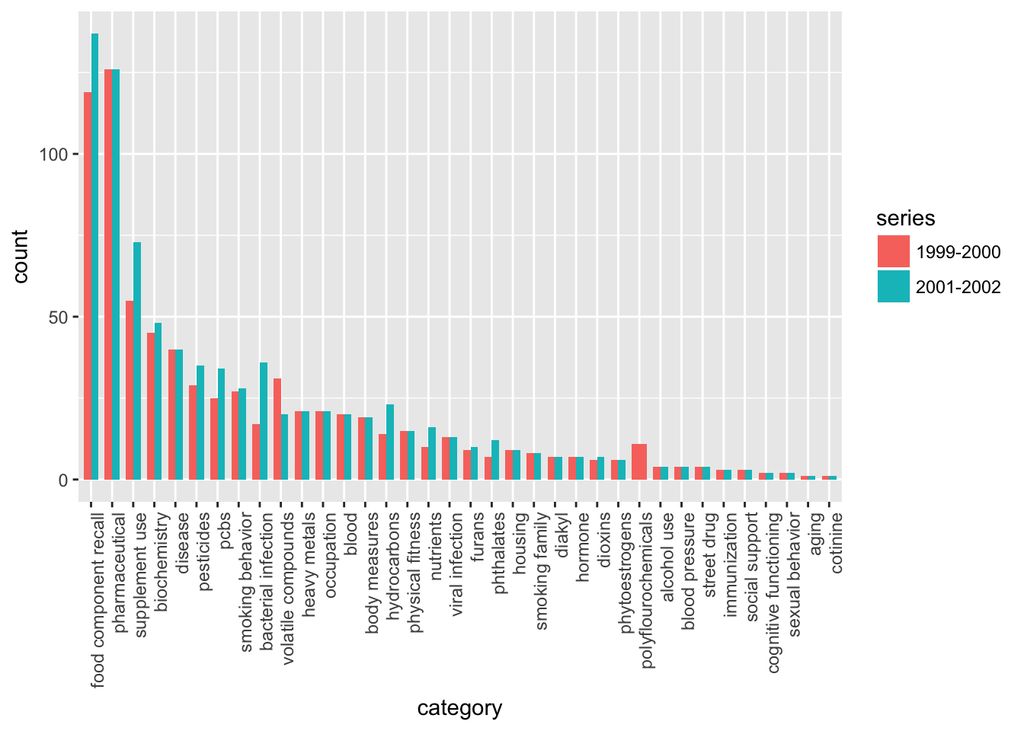

```r
VarDescription.telo$category <- factor(VarDescription.telo$category,levels=names(sort(table(VarDescription.telo$category), decreasing=TRUE)))
ggplot(VarDescription.telo, aes(x=category, fill=series)) + geom_bar(stat="count", width=0.7, position = position_dodge()) + theme(axis.text.x = element_text(angle = 90, hjust = 1))
```

### XWAS implementation!

#### Data preparation

##### 1: Identify the biomarkers of exposure - the X variables

For the sake of demonstration, we will just define the ‘X’ variables as those in the following categories:

- heavy metals
- PCBs
- cotinine

```r
useTheseCategories <- c( 'heavy metals','pcbs', 'cotinine')
useTheseCategories <- sort(useTheseCategories) # store pre-sorted for easier processing
VarDescription.telo <- VarDescription.telo[VarDescription.telo$category %in% useTheseCategories, ]
exposureVars <- unique(VarDescription.telo$var)
M <- length(exposureVars)
M # the numbner of X variables in our XWAS
```

```
## [1] 59
```

##### 2: identify the ‘adjustment’ variables

We’re close to performing the actual XWAS but will now define specific co-variates to adjust for in each regression. The vector is defined below as `adjustfor` and then the combined with unique co-variates in our cohort as well as the dependent variable of mean telomere length we are interested in studying (`TELOMEAN`).

We are also going to derive a new variable `RIDAGEYR2` which is the age-squared to adjust for non-linear effects associated with age.

```r
MainTable$RIDAGEYR2 <- MainTable$RIDAGEYR^2
```

The `newData` variable will contain all the pertinent records for analysis. In this snippet we will also create the survey design obeject that will serve as the cornerstone for future analyses. These will utilize the `survey` package and account for the cluster design and probability of selection of participants only keep those that have >0 weights (for later)

```r
adjustfor <- c('RIDAGEYR', 'RIDAGEYR2', 'female', 'mexican', 'black', 'other_eth', 'other_hispanic', 'INDFMPIR')

exposureVars <- setdiff(exposureVars, c("LBXDFS", "LBXDFSF","LBDDWS" )) ## lets remove the dust exposures for now
variablesToKeep <- c(exposureVars, 'TELOMEAN', adjustfor, 'SDMVPSU', 'SDMVSTRA', 'WTMEC2YR', 'WTMEC4YR')

newData <- subset(MainTable, SDDSRVYR <= 2)[, variablesToKeep] ## only keep those that are going to be analyzed (for simplicity)
newData <- subset(newData, WTMEC4YR > 0) ## # create the survey design object - this will account for the stratification of the survey
# we use the WTMEC4YR for the weights because we are testing individuals who visited the 'mobile examination center' (MEC) and we are combining the 1999-2000 and 2001-2002 data
dsn <- svydesign(ids=~SDMVPSU, strata=~SDMVSTRA, weight=~WTMEC4YR, nest=T, data=newData)
```

##### 3: Visualizing the Y variables, telomere length

We will now view the distribution of the variables

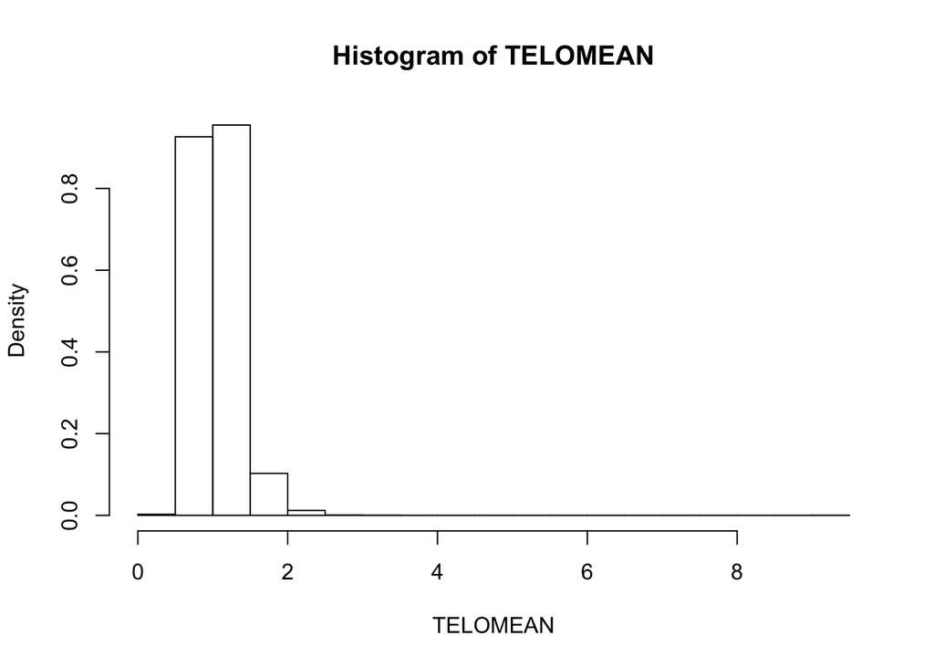

```r
svyhist(~TELOMEAN, dsn)
```

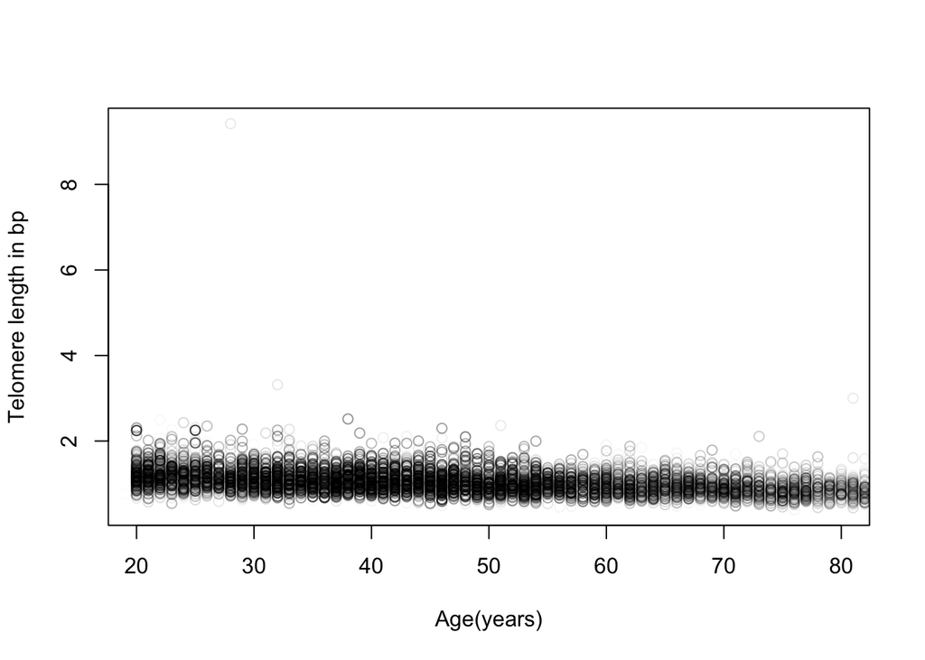

```r
svyplot(TELOMEAN ~ RIDAGEYR, dsn, xlab='Age(years)', ylab='Telomere length in bp', style='transparent', xlim=c(20, 80))
```

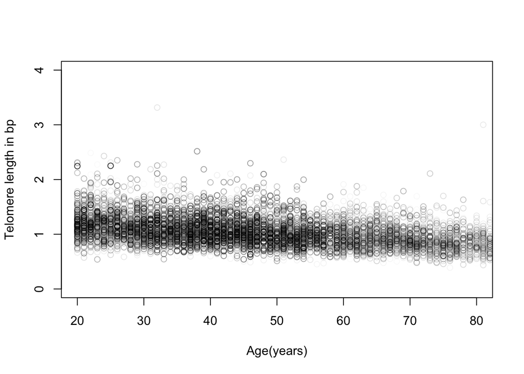

```r
svyplot(TELOMEAN ~ RIDAGEYR, dsn, xlab='Age(years)', ylab='Telomere length in bp', style='transparent', xlim=c(20, 80), ylim=c(0, 4))
```

```r
# what is the mean and the variance of telomeres?
svymean(~TELOMEAN, dsn, na.rm = T)
```

```
##            mean     SE
## TELOMEAN 1.0564 0.0146
```

```r
svyvar(~TELOMEAN, dsn, na.rm= T)
```

```
##          variance     SE
## TELOMEAN 0.076522 0.0075
```

```r
sqrt(svyvar(~TELOMEAN, dsn, na.rm= T))
```

```
##          variance     SE
## TELOMEAN  0.27663 0.0075
```

From the above plots, telomere length appears to be negatively associated with age (ie, telomeres are shorter for older individuals, which is in agreement with the literature).

Lets estimate the association size (or correlation) using linear regression.

##### 4. Conducting initial survey-weighted analyses of the Y and X

-First, we begin by associating telomere length with age, sex, race, and poverty

```r
mod <- svyglm(TELOMEAN ~ RIDAGEYR + RIDAGEYR2 +  female + black + mexican + other_hispanic + other_eth + INDFMPIR, dsn)
```

- How large are the association sizes for telomere length?
- What is the interpretation of each coefficient in telomere length? Which variable dominates, if any?
- which ones can you say are “statistically” not different than zero?
- interpret the coefficients.

```r
summary(mod)
```

```
##
## Call:
## svyglm(formula = TELOMEAN ~ RIDAGEYR + RIDAGEYR2 + female + black +
##     mexican + other_hispanic + other_eth + INDFMPIR, dsn)
##
## Survey design:
## svydesign(ids = ~SDMVPSU, strata = ~SDMVSTRA, weight = ~WTMEC4YR,
##     nest = T, data = newData)
##
## Coefficients:
##                  Estimate Std. Error t value Pr(>|t|)
## (Intercept)     1.344e+00  3.803e-02  35.354  < 2e-16 ***
## RIDAGEYR       -7.238e-03  1.491e-03  -4.854 8.46e-05 ***
## RIDAGEYR2       1.045e-05  1.395e-05   0.749   0.4622
## female          1.654e-02  8.046e-03   2.056   0.0524 .
## black           4.425e-02  1.730e-02   2.558   0.0183 *
## mexican        -4.437e-02  2.284e-02  -1.943   0.0656 .
## other_hispanic  2.443e-02  4.448e-02   0.549   0.5887
## other_eth      -1.376e-02  2.219e-02  -0.620   0.5418
## INDFMPIR        2.616e-03  4.571e-03   0.572   0.5732
## ---
## Signif. codes:  0 '***' 0.001 '**' 0.01 '*' 0.05 '.' 0.1 ' ' 1
##
## (Dispersion parameter for gaussian family taken to be 0.1008662)
##
## Number of Fisher Scoring iterations: 2
```

One can also scale the TELOMEAN variable (as we did in the paper) by the standard deviation - how does this change the interpretation?

```r
mod <- svyglm(I(scale(TELOMEAN)) ~ RIDAGEYR + RIDAGEYR2 +  female + black + mexican + other_hispanic + other_eth + INDFMPIR, dsn)
summary(mod)
```

```
##
## Call:
## svyglm(formula = I(scale(TELOMEAN)) ~ RIDAGEYR + RIDAGEYR2 +
##     female + black + mexican + other_hispanic + other_eth + INDFMPIR,
##     dsn)
##
## Survey design:
## svydesign(ids = ~SDMVPSU, strata = ~SDMVSTRA, weight = ~WTMEC4YR,
##     nest = T, data = newData)
##
## Coefficients:
##                  Estimate Std. Error t value Pr(>|t|)
## (Intercept)     1.125e+00  1.356e-01   8.301 4.53e-08 ***
## RIDAGEYR       -2.581e-02  5.316e-03  -4.854 8.46e-05 ***
## RIDAGEYR2       3.725e-05  4.975e-05   0.749   0.4622
## female          5.898e-02  2.869e-02   2.056   0.0524 .
## black           1.578e-01  6.168e-02   2.558   0.0183 *
## mexican        -1.582e-01  8.142e-02  -1.943   0.0656 .
## other_hispanic  8.709e-02  1.586e-01   0.549   0.5887
## other_eth      -4.907e-02  7.912e-02  -0.620   0.5418
## INDFMPIR        9.325e-03  1.630e-02   0.572   0.5732
## ---
## Signif. codes:  0 '***' 0.001 '**' 0.01 '*' 0.05 '.' 0.1 ' ' 1
##
## (Dispersion parameter for gaussian family taken to be 1.282078)
##
## Number of Fisher Scoring iterations: 2
```

Now lets examine some of the exposure biomarkers, such as serum heavy metal lead.

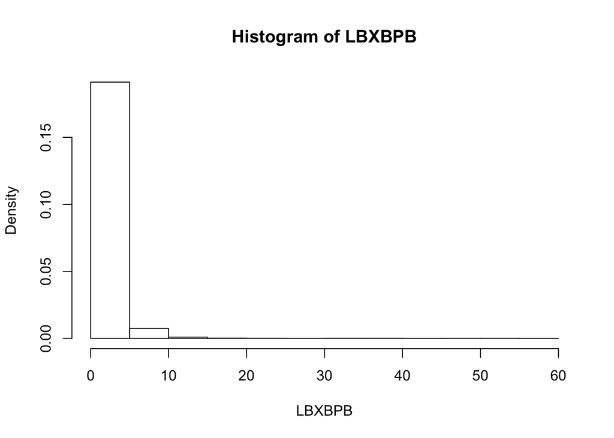

```r
svyhist(~LBXBPB, dsn)
```

Looks like a long-tailed distribution - lets log transform.

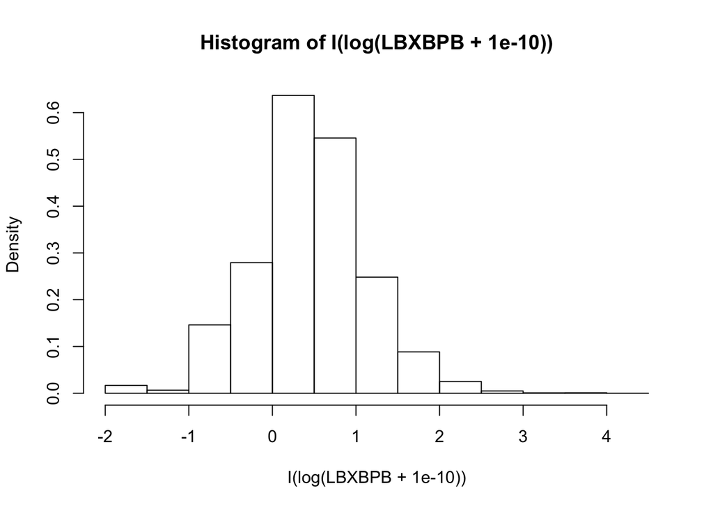

```r
svyhist(~I(log(LBXBPB+1e-10)), dsn)
```

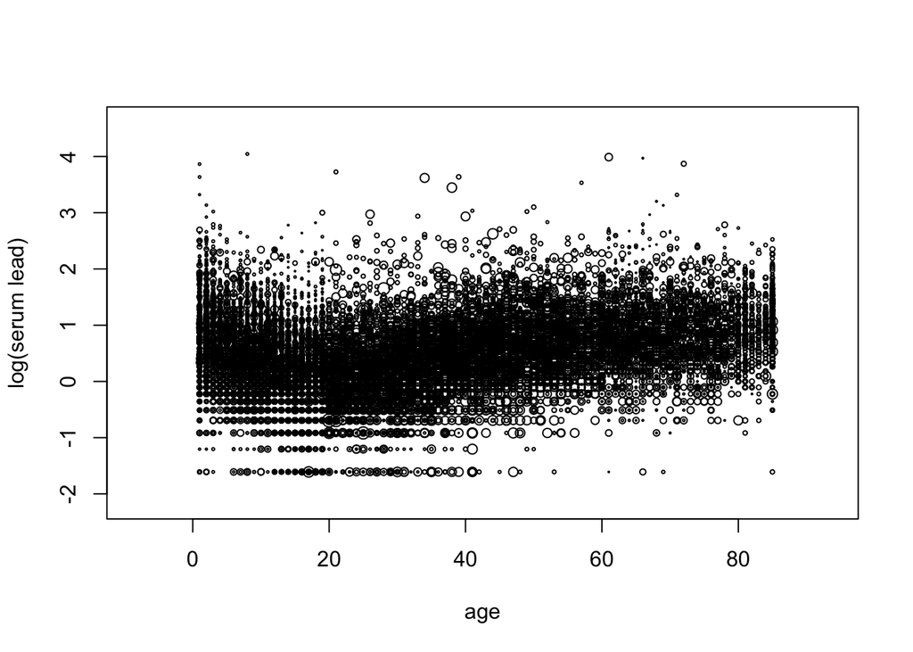

```r
svyplot(I(log(LBXBPB+1e-10)) ~ RIDAGEYR, dsn, ylab='log(serum lead)', xlab='age')
```

Is serum lead associated with other demographic factors? Yes! It appears to be strongly associated with sex, mexican vs. whites, blacks vs. whites, and income!

```r
mod <- svyglm(I(log(LBXBPB+1e-10)) ~ RIDAGEYR +  RIDAGEYR2 + female +  mexican + black + other_eth + other_hispanic + INDFMPIR, dsn)
summary(mod)
```

```
##
## Call:
## svyglm(formula = I(log(LBXBPB + 1e-10)) ~ RIDAGEYR + RIDAGEYR2 +
##     female + mexican + black + other_eth + other_hispanic + INDFMPIR,
##     dsn)
##
## Survey design:
## svydesign(ids = ~SDMVPSU, strata = ~SDMVSTRA, weight = ~WTMEC4YR,
##     nest = T, data = newData)
##
## Coefficients:
##                  Estimate Std. Error t value Pr(>|t|)
## (Intercept)     5.038e-01  3.595e-02  14.013 3.97e-12 ***
## RIDAGEYR        1.443e-03  1.295e-03   1.114  0.27792
## RIDAGEYR2       1.197e-04  1.432e-05   8.361 4.03e-08 ***
## female         -4.293e-01  1.249e-02 -34.364  < 2e-16 ***
## mexican         1.219e-01  3.364e-02   3.623  0.00159 **
## black           1.909e-01  2.071e-02   9.217 7.92e-09 ***
## other_eth      -2.187e-02  3.610e-02  -0.606  0.55122
## other_hispanic  6.949e-03  5.059e-02   0.137  0.89205
## INDFMPIR       -5.640e-02  5.148e-03 -10.956 3.82e-10 ***
## ---
## Signif. codes:  0 '***' 0.001 '**' 0.01 '*' 0.05 '.' 0.1 ' ' 1
##
## (Dispersion parameter for gaussian family taken to be 0.3769761)
##
## Number of Fisher Scoring iterations: 2
```

The exposure biomarker data is right-skewed and seemingly correlated with age and other sociodemographic factors. For our regressions, we log transform the data and copy it into a new object for analysis

```r
newLogData <- newData
newLogData[, exposureVars] <- log(newLogData[, exposureVars] + 1e-10)
dsn <- svydesign(ids=~SDMVPSU, strata=~SDMVSTRA, weight=~WTMEC4YR, nest=T, data=newLogData) # create the design object
```

##### 5. XWAS pipeline

Recall the pseudo-algorithm:

1. y = [blood pressure values for cohort]
2. association_list = empty_list()
3. for each x in list of exposures:
- association_test=f(x,y)
- append(association_list, association_test)
4. multiplicity_correct(association_list)

First we define some ‘helper’ functions that do the individual association tests (using linear regression) in step 3a: `buildFormula` builds a formula out of a string for linear regression

```r
buildFormula <- function(exposureVar, adjustmentVariables = adjustfor) {
  # scaling both telomere length and the exposure
  # what will be the interpretation?
  as.formula(sprintf('I(scale(%s)) ~ I(scale(%s)) + %s', 'TELOMEAN', exposureVar, paste(adjustmentVariables, collapse="+")))
}

testFormula <- buildFormula('LBXBPB')
print(testFormula)
```

```
## I(scale(TELOMEAN)) ~ I(scale(LBXBPB)) + RIDAGEYR + RIDAGEYR2 +
##     female + mexican + black + other_eth + other_hispanic + INDFMPIR
## <environment: 0x7fda972631f8>
```

```r
# test it
test_mod <- svyglm(testFormula, dsn)
print(tidy((test_mod))) ## cool, we got one regression to work... now we need to scale this up! [the function tidy is cool, too -- enables us to get a clean data.frame output from a regression model]
```

```
##                term      estimate    std.error  statistic      p.value
## 1       (Intercept)  1.1156097869 1.492950e-01  7.4725204 3.288881e-07
## 2  I(scale(LBXBPB)) -0.0094496873 2.947552e-02 -0.3205944 7.518434e-01
## 3          RIDAGEYR -0.0252147228 5.862675e-03 -4.3008906 3.481394e-04
## 4         RIDAGEYR2  0.0000331111 5.203219e-05  0.6363580 5.317592e-01
## 5            female  0.0529338431 4.227348e-02  1.2521763 2.249515e-01
## 6           mexican -0.1572992256 8.246896e-02 -1.9073750 7.093713e-02
## 7             black  0.1583513604 6.280212e-02  2.5214334 2.028234e-02
## 8         other_eth -0.0505875195 7.887970e-02 -0.6413250 5.285933e-01
## 9    other_hispanic  0.0867379541 1.574718e-01  0.5508158 5.878607e-01
## 10         INDFMPIR  0.0081731909 1.627511e-02  0.5021895 6.210184e-01
```

```r
association_list <- data.frame() # step 2 of algorithm
for(exposure in exposureVars) {
  model <- buildFormula(exposure)
  #print(model)
  ## now run the association
  mod <- svyglm(model, dsn) # step 3a
  modFrame <- tidy(mod)
  modFrame$variable <- exposure
  association_list <- rbind(association_list, modFrame) # step 3b of algorithm
}


## we collected the entire model, including adjustment covariates.
## filter them out to just look at the exposure associations
xwas_association_list <- association_list[!(association_list$term %in% adjustfor), ]
xwas_association_list <- xwas_association_list[!(xwas_association_list$term %in% '(Intercept)'), ]
```

###### Multiplicity correction: controlling the ‘False Discovery Rate’

- use the Benjamini-Yekuteli step-down method to control the False Discovery Rate: https://projecteuclid.org/euclid.aos/1013699998

```r
xwas_association_list$fdr <- p.adjust(xwas_association_list$p.value, method='BY') # elegance in one line of code. (We can also use permutation-based estimations)
```

###### Visualize: Volcano Plots

- Association size vs. -log10(pvalue)
- we draw a signficance threshold where FDR is controlled at 5%. This is the max pvalue that achieves FDR less than 5%

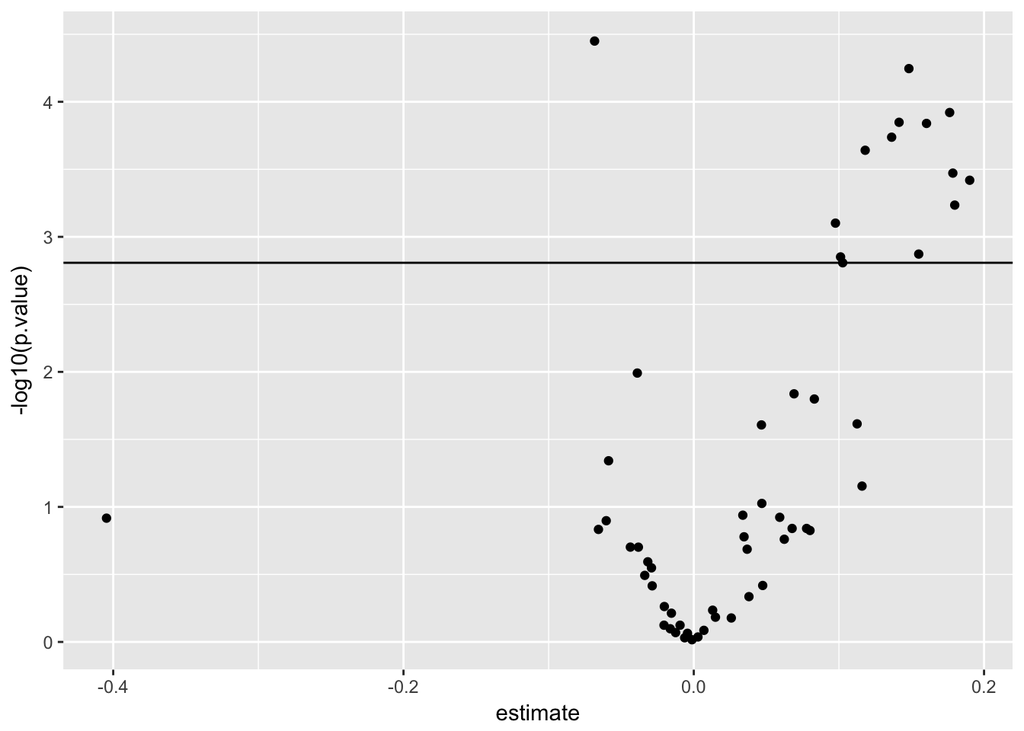

```r
pvalue_threshold <- max(xwas_association_list[which(xwas_association_list$fdr < 0.05), 'p.value'])
volcano_plot <- ggplot(xwas_association_list, aes(estimate, -log10(p.value)))
volcano_plot <- volcano_plot + geom_point()
volcano_plot <- volcano_plot + geom_hline(yintercept=-log10(pvalue_threshold))
volcano_plot
```

###### Table of estimates.

- Remember that the units are coming straight from the data dictionary and are NOT applicable here (we scaled each variable to have 1SD units in the log space, so therefore the interpretation will not be in the original units [ie, ng/g])
- How would you interpret each estimate?
- Hint: “For a 1SD change in the natural log of the biomarker of exposure = ???? change in telomere length…”

```r
xwas_association_list <- merge(xwas_association_list, unique(VarDescription.telo[, c('var', 'var_desc')]), by.x='variable', by.y='var')
## shave off the units from the variable description as we re-scaled the variables
xwas_association_list$var_desc <- sub(' \\(.+\\)', '', xwas_association_list$var_desc)
xwas_association_list <- xwas_association_list[order(xwas_association_list$fdr, decreasing = F),]
knitr::kable(subset(xwas_association_list, fdr < 0.05)[, c('var_desc', 'estimate', 'p.value', 'fdr')])
```

|  | var_desc | estimate | p.value | fdr |
| --- | --- | --- | --- | --- |
| 23 | PCB170 | 0.1482284 | 0.0000568 | 0.0073302 |
| 35 | Cadmium | -0.0683392 | 0.0000355 | 0.0073302 |
| 9 | PCB99 | 0.1414589 | 0.0001419 | 0.0074670 |
| 15 | PCB138 | 0.1763144 | 0.0001200 | 0.0074670 |
| 38 | 3,3’,4,4’,5,5’-hxcb | 0.1603625 | 0.0001446 | 0.0074670 |
| 29 | PCB187 | 0.1363342 | 0.0001829 | 0.0078707 |
| 20 | PCB156 | 0.1181088 | 0.0002285 | 0.0084300 |
| 27 | PCB180 | 0.1784980 | 0.0003373 | 0.0108891 |
| 19 | PCB153 | 0.1901212 | 0.0003810 | 0.0109318 |
| 7 | PCB74 | 0.1798091 | 0.0005821 | 0.0150312 |
| 16 | PCB146 | 0.0976195 | 0.0007915 | 0.0185824 |
| 13 | PCB118 | 0.1549948 | 0.0013418 | 0.0279728 |
| 43 | Mercury, total | 0.1011418 | 0.0014082 | 0.0279728 |
| 41 | 3,3’,4,4’,5-pncb | 0.1026033 | 0.0015562 | 0.0287063 |

### Questions:

- Send a ‘pull’ request in GitHub to incorporate your answers in a new version of the .Rmd or R code!
- https://services.github.com/on-demand/github-cli/open-pull-request-github
0. What is your interpretation of the association sizes and pvalues for your XWAS?
1. How much to the coefficients change for the adjustment variables for each of the correlations?
2. Attempt to reproduce the findings in Patel et al., IJE 2016 (https://www.ncbi.nlm.nih.gov/pubmed/27059547) using more categories of exposure. How will you handle other X variables, such as self-reported variables?
3. When increasing the number of variables, how would the pvalue threshold change to accommodate more tests? How would the FDR change, if at all?
4. Execute the XWAS in another phenotype. What are the similarties and differences between your analysis in 1.
5. How much variance explained in telomeres do the top factors explain? Is this to be expected?
6. Implement the XWAS without using the `for` operator using the tidyverse suite of commands.